# major_project

Seasonal Agriculture Performance Analysis. 📋 Major Data Analysis Project Domain: Agriculture Theme: Seasonal Agriculture Performance Core Goal: Analyze how agricultural performance varies across different seasons. You need to uncover patterns, trends, relationships, and statistical differences using the provided dataset. Tech Stack: Python, Pandas, NumPy, Matplotlib, and Seaborn.

```python
import numpy as np
import pandas as pd
import matplotlib.pyplot as plt
import seaborn as sns
```

```python
df= pd.read_csv("seasonal_agriculture_performance_dataset.csv")

print("Dataset loaded successfully.")
```

```
Dataset loaded successfully.
```

```python
#review top 5 rows
df.head()
```

|  | Farm_ID | State | District | Crop | Season | Farm_Area_Hectares | Rainfall_mm | Avg_Temperature_C | Humidity_pct | Sunlight_Hours_Day | ... | Seed_Quality_Score | Yield_Tonnes_Ha | Production_Tonnes | Market_Price_INR_Tonne | Total_Cost_INR | Revenue_INR | Profit_INR | Water_Used_m3 | Water_Efficiency_t_per_1000m3 | Disease_Pest_Risk_pct |
| --- | --- | --- | --- | --- | --- | --- | --- | --- | --- | --- | --- | --- | --- | --- | --- | --- | --- | --- | --- | --- | --- |
| 0 | SF10001 | Andhra Pradesh | Rajkot | Wheat | Kharif | 0.53 | 486.4 | 24.3 | 69.1 | 5.8 | ... | 0.76 | 2.46 | 1.30 | 23700 | 42662 | 30810 | -11852 | 237 | 5.485 | 55.3 |
| 1 | SF10002 | Maharashtra | Nalgonda | Maize | Kharif | 6.53 | 855.4 | 25.7 | 78.4 | 5.1 | ... | 0.94 | 0.30 | 1.96 | 20613 | 492351 | 40401 | -451950 | 4953 | 0.396 | 49.9 |
| 2 | SF10003 | Telangana | Warangal | Pulses | Rabi | 4.86 | 455.6 | 23.9 | 56.4 | 10.3 | ... | 0.98 | 0.52 | 2.53 | 75283 | 315210 | 190466 | -124744 | 1275 | 1.984 | 33.7 |
| 3 | SF10004 | Telangana | Indore | Rice | Kharif | 4.50 | 753.2 | 29.7 | 65.2 | 6.3 | ... | 0.74 | 1.84 | 8.28 | 24244 | 296444 | 200740 | -95704 | 3834 | 2.160 | 50.6 |
| 4 | SF10005 | Karnataka | Ludhiana | Maize | Zaid | 4.21 | 101.6 | 34.1 | 55.2 | 6.5 | ... | 0.90 | 2.21 | 9.30 | 20818 | 337959 | 193607 | -144352 | 3287 | 2.829 | 32.3 |

5 rows × 28 columns

```python
#Last five rows.
df.tail()
```

|  | Farm_ID | State | District | Crop | Season | Farm_Area_Hectares | Rainfall_mm | Avg_Temperature_C | Humidity_pct | Sunlight_Hours_Day | ... | Seed_Quality_Score | Yield_Tonnes_Ha | Production_Tonnes | Market_Price_INR_Tonne | Total_Cost_INR | Revenue_INR | Profit_INR | Water_Used_m3 | Water_Efficiency_t_per_1000m3 | Disease_Pest_Risk_pct |
| --- | --- | --- | --- | --- | --- | --- | --- | --- | --- | --- | --- | --- | --- | --- | --- | --- | --- | --- | --- | --- | --- |
| 3995 | SF13996 | Karnataka | Rajkot | Wheat | Kharif | 4.72 | 865.4 | 27.3 | 51.4 | 6.3 | ... | 0.74 | 0.51 | 2.41 | 22717 | 362917 | 54748 | -308169 | 2016 | 1.195 | 45.2 |
| 3996 | SF13997 | Karnataka | Krishna | Chilli | Kharif | 8.77 | 947.5 | 29.2 | 85.5 | 6.1 | ... | 0.80 | 2.75 | 24.12 | 106459 | 496471 | 2567791 | 2071320 | 5351 | 4.508 | 59.7 |
| 3997 | SF13998 | Andhra Pradesh | Erode | Pulses | Zaid | 10.47 | 80.0 | 35.4 | 68.5 | 8.6 | ... | 0.99 | 0.62 | 6.49 | 66860 | 785632 | 433921 | -351711 | 3392 | 1.913 | 29.2 |
| 3998 | SF13999 | Punjab | Warangal | Cotton | Kharif | 1.73 | 475.0 | 28.2 | 61.7 | 6.4 | ... | 0.98 | 1.35 | 2.34 | 75282 | 153904 | 176160 | 22256 | 1220 | 1.918 | 50.4 |
| 3999 | SF14000 | Punjab | Nashik | Wheat | Kharif | 3.31 | 984.3 | 25.8 | 77.2 | 5.9 | ... | 0.99 | 2.36 | 7.81 | 28812 | 263872 | 225022 | -38850 | 1800 | 4.339 | 62.3 |

5 rows × 28 columns

```python
#Number of columns and rows
df.shape
```

```
(4000, 28)
```

```python
#column names
df.columns.to_list()
```

```
['Farm_ID',
 'State',
 'District',
 'Crop',
 'Season',
 'Farm_Area_Hectares',
 'Rainfall_mm',
 'Avg_Temperature_C',
 'Humidity_pct',
 'Sunlight_Hours_Day',
 'Soil_pH',
 'Soil_Moisture_pct',
 'Nitrogen_kg_ha',
 'Phosphorus_kg_ha',
 'Potassium_kg_ha',
 'Irrigation_Method',
 'Fertilizer_kg_ha',
 'Pesticide_Litre_ha',
 'Seed_Quality_Score',
 'Yield_Tonnes_Ha',
 'Production_Tonnes',
 'Market_Price_INR_Tonne',
 'Total_Cost_INR',
 'Revenue_INR',
 'Profit_INR',
 'Water_Used_m3',
 'Water_Efficiency_t_per_1000m3',
 'Disease_Pest_Risk_pct']
```

```python
#data types
df.info()
```

```
<class 'pandas.DataFrame'>
RangeIndex: 4000 entries, 0 to 3999
Data columns (total 28 columns):
 #   Column                         Non-Null Count  Dtype
---  ------                         --------------  -----
 0   Farm_ID                        4000 non-null   str
 1   State                          4000 non-null   str
 2   District                       4000 non-null   str
 3   Crop                           4000 non-null   str
 4   Season                         4000 non-null   str
 5   Farm_Area_Hectares             4000 non-null   float64
 6   Rainfall_mm                    3952 non-null   float64
 7   Avg_Temperature_C              4000 non-null   float64
 8   Humidity_pct                   4000 non-null   float64
 9   Sunlight_Hours_Day             4000 non-null   float64
```

[output cut: 20 more lines]

```python
#stastical info
df.describe(include='all').T
```

|  | count | unique | top | freq | mean | std | min | 25% | 50% | 75% | max |
| --- | --- | --- | --- | --- | --- | --- | --- | --- | --- | --- | --- |
| Farm_ID | 4000 | 4000 | SF10001 | 1 | NaN | NaN | NaN | NaN | NaN | NaN | NaN |
| State | 4000 | 8 | Andhra Pradesh | 529 | NaN | NaN | NaN | NaN | NaN | NaN | NaN |
| District | 4000 | 10 | Ludhiana | 427 | NaN | NaN | NaN | NaN | NaN | NaN | NaN |
| Crop | 4000 | 8 | Rice | 690 | NaN | NaN | NaN | NaN | NaN | NaN | NaN |
| Season | 4000 | 3 | Kharif | 1779 | NaN | NaN | NaN | NaN | NaN | NaN | NaN |
| Farm_Area_Hectares | 4000.0 | NaN | NaN | NaN | 7.888265 | 4.223764 | 0.5 | 4.26 | 7.895 | 11.65 | 15.0 |
| Rainfall_mm | 3952.0 | NaN | NaN | NaN | 601.152657 | 288.925025 | 80.0 | 370.2 | 582.0 | 834.95 | 1395.2 |
| Avg_Temperature_C | 4000.0 | NaN | NaN | NaN | 26.8189 | 3.81818 | 16.2 | 23.9 | 26.9 | 29.6 | 39.7 |
| Humidity_pct | 4000.0 | NaN | NaN | NaN | 63.2105 | 11.960834 | 25.0 | 54.775 | 63.0 | 71.9 | 95.0 |
| Sunlight_Hours_Day | 4000.0 | NaN | NaN | NaN | 7.32305 | 1.121186 | 3.5 | 6.6 | 7.3 | 8.1 | 11.0 |
| Soil_pH | 4000.0 | NaN | NaN | NaN | 6.70101 | 0.641461 | 5.2 | 6.26 | 6.69 | 7.14 | 8.4 |
| Soil_Moisture_pct | 3960.0 | NaN | NaN | NaN | 26.508232 | 6.712484 | 8.0 | 21.7 | 26.4 | 31.3 | 47.0 |
| Nitrogen_kg_ha | 4000.0 | NaN | NaN | NaN | 120.250825 | 31.216452 | 40.0 | 98.5 | 120.1 | 141.225 | 220.0 |
| Phosphorus_kg_ha | 4000.0 | NaN | NaN | NaN | 57.78185 | 17.015074 | 15.0 | 46.2 | 57.5 | 69.4 | 120.0 |
| Potassium_kg_ha | 4000.0 | NaN | NaN | NaN | 104.76005 | 27.742681 | 30.0 | 86.2 | 105.1 | 123.6 | 200.0 |
| Irrigation_Method | 4000 | 4 | Flood | 1310 | NaN | NaN | NaN | NaN | NaN | NaN | NaN |
| Fertilizer_kg_ha | 4000.0 | NaN | NaN | NaN | 186.036 | 60.260583 | 40.0 | 143.975 | 186.25 | 227.2 | 400.0 |
| Pesticide_Litre_ha | 4000.0 | NaN | NaN | NaN | 5.070935 | 1.978879 | 0.5 | 3.69 | 5.12 | 6.4 | 12.08 |
| Seed_Quality_Score | 4000.0 | NaN | NaN | NaN | 0.826138 | 0.101747 | 0.65 | 0.74 | 0.83 | 0.91 | 1.0 |
| Yield_Tonnes_Ha | 3968.0 | NaN | NaN | NaN | 5.270595 | 13.361398 | 0.3 | 1.05 | 1.74 | 2.84 | 101.44 |
| Production_Tonnes | 4000.0 | NaN | NaN | NaN | 43.24621 | 126.880521 | 0.15 | 5.02 | 11.77 | 24.355 | 1424.4 |
| Market_Price_INR_Tonne | 4000.0 | NaN | NaN | NaN | 44714.16625 | 30266.161922 | 2594.0 | 21429.25 | 25913.0 | 68279.0 | 131240.0 |
| Total_Cost_INR | 4000.0 | NaN | NaN | NaN | 526303.583 | 294419.140911 | 26826.0 | 274577.5 | 519082.5 | 761996.5 | 1349990.0 |
| Revenue_INR | 4000.0 | NaN | NaN | NaN | 637860.048 | 636974.710054 | 6107.0 | 207517.25 | 456830.5 | 836874.75 | 5080900.0 |
| Profit_INR | 4000.0 | NaN | NaN | NaN | 111556.465 | 545081.890509 | -1019223.0 | -148731.75 | 3673.0 | 216187.75 | 4345421.0 |
| Water_Used_m3 | 4000.0 | NaN | NaN | NaN | 6045.57025 | 5572.944306 | 128.0 | 2268.75 | 4435.0 | 7829.75 | 40902.0 |
| Water_Efficiency_t_per_1000m3 | 4000.0 | NaN | NaN | NaN | 5.385214 | 8.838101 | 0.135 | 1.661 | 2.9375 | 5.15025 | 79.8 |
| Disease_Pest_Risk_pct | 4000.0 | NaN | NaN | NaN | 46.365875 | 12.424417 | 5.0 | 37.3 | 46.4 | 54.9 | 88.9 |

```python
from os import dup
#data quality check
duplicate_count = df.duplicated().sum()
print('Duplicate Rows',duplicate_count)
```

```
Duplicate Rows 0
```

```python
df = df.drop_duplicates().copy()
print('Duplicates remaining',df.duplicated().sum())
```

```
Duplicates remaining 0
```

```python
missing = pd.DataFrame({
    'Missing Count': df.isna().sum(),
    'Missing %': (df.isna().mean() * 100).round(2)
})

missing = missing[missing['Missing Count'] > 0]
missing.sort_values('Missing Count', ascending=False)
```

|  | Missing Count | Missing % |
| --- | --- | --- |
| Rainfall_mm | 48 | 1.2 |
| Soil_Moisture_pct | 40 | 1.0 |
| Yield_Tonnes_Ha | 32 | 0.8 |

```python
df = df.drop_duplicates().reset_index(drop=True)
print("Shape after removing duplicates:", df.shape)
```

```
Shape after removing duplicates: (4000, 28)
```

```python
df.dtypes
```

```
Farm_ID                              str
State                                str
District                             str
Crop                                 str
Season                               str
Farm_Area_Hectares               float64
Rainfall_mm                      float64
Avg_Temperature_C                float64
Humidity_pct                     float64
Sunlight_Hours_Day               float64
Soil_pH                          float64
Soil_Moisture_pct                float64
Nitrogen_kg_ha                   float64
Phosphorus_kg_ha                 float64
Potassium_kg_ha                  float64
Irrigation_Method                    str
Fertilizer_kg_ha                 float64
Pesticide_Litre_ha               float64
Seed_Quality_Score               float64
Yield_Tonnes_Ha                  float64
Production_Tonnes                float64
Market_Price_INR_Tonne             int64
Total_Cost_INR                     int64
Revenue_INR                        int64
Profit_INR                         int64
Water_Used_m3                      int64
Water_Efficiency_t_per_1000m3    float64
Disease_Pest_Risk_pct            float64
dtype: object
```

```python
# Check unique values for categorical columns

categorical_columns = df.select_dtypes(include=["str"]).columns

for col in categorical_columns:
    print(f"\n{col}:")
    print(df[col].nunique(), "unique values")
    print(df[col].dropna().unique()[:20])
```

```
Farm_ID:
4000 unique values
<ArrowStringArray>
['SF10001', 'SF10002', 'SF10003', 'SF10004', 'SF10005', 'SF10006', 'SF10007',
 'SF10008', 'SF10009', 'SF10010', 'SF10011', 'SF10012', 'SF10013', 'SF10014',
 'SF10015', 'SF10016', 'SF10017', 'SF10018', 'SF10019', 'SF10020']
Length: 20, dtype: str

State:
8 unique values
<ArrowStringArray>
['Andhra Pradesh',    'Maharashtra',      'Telangana',      'Karnataka',
        'Gujarat',     'Tamil Nadu',         'Punjab', 'Madhya Pradesh']
Length: 8, dtype: str

District:
10 unique values
<ArrowStringArray>
[  'Rajkot', 'Nalgonda', 'Warangal',   'Indore', 'Ludhiana',  'Raichur',
   'Guntur',  'Krishna',   'Nashik',    'Erode']
Length: 10, dtype: str

Crop:
8 unique values
<ArrowStringArray>
[    'Wheat',     'Maize',    'Pulses',      'Rice',    'Cotton',    'Chilli',
 'Groundnut', 'Sugarcane']
Length: 8, dtype: str

Season:
3 unique values
<ArrowStringArray>
['Kharif', 'Rabi', 'Zaid']
Length: 3, dtype: str

Irrigation_Method:
4 unique values
<ArrowStringArray>
['Drip', 'Flood', 'Rainfed', 'Sprinkler']
Length: 4, dtype: str
```

```python
# Example: median imputation for numerical columns

numeric_columns = df.select_dtypes(include=np.number).columns

for col in numeric_columns:
    if df[col].isnull().sum() > 0:
        df[col] = df[col].fillna(df[col].median())

print("Remaining missing values:", df.isnull().sum().sum())
```

```
Remaining missing values: 0
```

Univariate analysis examines one variable at a time to understand its distribution, central tendency, variability, and unusual values. For a Seasonal Agriculture Performance Analysis, it helps identify how individual agricultural factors—such as crop production, yield, rainfall, cultivated area, and prices—behave across observations or seasons.

```python
# Numerical and categorical columns

numeric_columns = df.select_dtypes(include=np.number).columns.tolist()
categorical_columns = df.select_dtypes(include="str").columns.tolist()

print("Numerical columns:")
print(numeric_columns)

print("\nCategorical columns:")
print(categorical_columns)
```

```
Numerical columns:
['Farm_Area_Hectares', 'Rainfall_mm', 'Avg_Temperature_C', 'Humidity_pct', 'Sunlight_Hours_Day', 'Soil_pH', 'Soil_Moisture_pct', 'Nitrogen_kg_ha', 'Phosphorus_kg_ha', 'Potassium_kg_ha', 'Fertilizer_kg_ha', 'Pesticide_Litre_ha', 'Seed_Quality_Score', 'Yield_Tonnes_Ha', 'Production_Tonnes', 'Market_Pr…

Categorical columns:
['Farm_ID', 'State', 'District', 'Crop', 'Season', 'Irrigation_Method']
```

```python
# Define the summary dictionary using your aggregated metrics
statistical_summary = pd.DataFrame({
    "Mean": df[numeric_columns].mean(),
    "Median": df[numeric_columns].median(),
    "Std_Dev": df[numeric_columns].std(),
    "Min": df[numeric_columns].min(),
    "Max": df[numeric_columns].max()
})

# Display the summary table
print(statistical_summary)
```

```
                                        Mean       Median        Std_Dev  \
Farm_Area_Hectares                  7.888265       7.8950       4.223764
Rainfall_mm                       600.922825     582.0000     287.193381
Avg_Temperature_C                  26.818900      26.9000       3.818180
Humidity_pct                       63.210500      63.0000      11.960834
Sunlight_Hours_Day                  7.323050       7.3000       1.121186
Soil_pH                             6.701010       6.6900       0.641461
Soil_Moisture_pct                  26.507150      26.4000       6.678837
Nitrogen_kg_ha                    120.250825     120.1000      31.216452
Phosphorus_kg_ha                   57.781850      57.5000      17.015074
Potassium_kg_ha                   104.760050     105.1000      27.742681
Fertilizer_kg_ha                  186.036000     186.2500      60.260583
Pesticide_Litre_ha                  5.070935       5.1200       1.978879
Seed_Quality_Score                  0.826138       0.8300       0.101747
Yield_Tonnes_Ha                     5.242350       1.7400      13.311549
Production_Tonnes                  43.246210      11.7700     126.880521
Market_Price_INR_Tonne          44714.166250   25913.0000   30266.161922
Total_Cost_INR                 526303.583000  519082.5000  294419.140911
Revenue_INR                    637860.048000  456830.5000  636974.710054
Profit_INR                     111556.465000    3673.0000  545081.890509
Water_Used_m3                    6045.570250    4435.0000    5572.944306
Water_Efficiency_t_per_1000m3       5.385214       2.9375       8.838101
Disease_Pest_Risk_pct              46.365875      46.4000      12.424417

                                       Min         Max
Farm_Area_Hectares                   0.500       15.00
Rainfall_mm                         80.000     1395.20
Avg_Temperature_C                   16.200       39.70
Humidity_pct                        25.000       95.00
Sunlight_Hours_Day                   3.500       11.00
Soil_pH                              5.200        8.40
Soil_Moisture_pct                    8.000       47.00
Nitrogen_kg_ha                      40.000      220.00
Phosphorus_kg_ha                    15.000      120.00
Potassium_kg_ha                     30.000      200.00
Fertilizer_kg_ha                    40.000      400.00
Pesticide_Litre_ha                   0.500       12.08
Seed_Quality_Score                   0.650        1.00
Yield_Tonnes_Ha                      0.300      101.44
Production_Tonnes                    0.150     1424.40
Market_Price_INR_Tonne            2594.000   131240.00
Total_Cost_INR                   26826.000  1349990.00
Revenue_INR                       6107.000  5080900.00
Profit_INR                    -1019223.000  4345421.00
Water_Used_m3                      128.000    40902.00
Water_Efficiency_t_per_1000m3        0.135       79.80
Disease_Pest_Risk_pct                5.000       88.90
```

```python
 #1. Generate the base summary statistics and transpose it (.T)
# This creates the rows for each column and columns for count, mean, std, min, 25%, 50%, 75%, max
import pandas as pd
df=pd.read_csv("seasonal_agriculture_performance_dataset.csv")
summary = df.describe().T

# 2. Calculate the 'range' column (max - min)
summary['range'] = summary['max'] - summary['min']

# 3. Calculate the 'IQR' column (75% percentile - 25% percentile)
summary['IQR'] = summary['75%'] - summary['25%']
summary=summary.round(2)
summary
```

|  | count | mean | std | min | 25% | 50% | 75% | max | range | IQR |
| --- | --- | --- | --- | --- | --- | --- | --- | --- | --- | --- |
| Farm_Area_Hectares | 4000.0 | 7.89 | 4.22 | 0.50 | 4.26 | 7.90 | 11.65 | 15.00 | 14.50 | 7.39 |
| Rainfall_mm | 3952.0 | 601.15 | 288.93 | 80.00 | 370.20 | 582.00 | 834.95 | 1395.20 | 1315.20 | 464.75 |
| Avg_Temperature_C | 4000.0 | 26.82 | 3.82 | 16.20 | 23.90 | 26.90 | 29.60 | 39.70 | 23.50 | 5.70 |
| Humidity_pct | 4000.0 | 63.21 | 11.96 | 25.00 | 54.78 | 63.00 | 71.90 | 95.00 | 70.00 | 17.13 |
| Sunlight_Hours_Day | 4000.0 | 7.32 | 1.12 | 3.50 | 6.60 | 7.30 | 8.10 | 11.00 | 7.50 | 1.50 |
| Soil_pH | 4000.0 | 6.70 | 0.64 | 5.20 | 6.26 | 6.69 | 7.14 | 8.40 | 3.20 | 0.88 |
| Soil_Moisture_pct | 3960.0 | 26.51 | 6.71 | 8.00 | 21.70 | 26.40 | 31.30 | 47.00 | 39.00 | 9.60 |
| Nitrogen_kg_ha | 4000.0 | 120.25 | 31.22 | 40.00 | 98.50 | 120.10 | 141.22 | 220.00 | 180.00 | 42.72 |
| Phosphorus_kg_ha | 4000.0 | 57.78 | 17.02 | 15.00 | 46.20 | 57.50 | 69.40 | 120.00 | 105.00 | 23.20 |
| Potassium_kg_ha | 4000.0 | 104.76 | 27.74 | 30.00 | 86.20 | 105.10 | 123.60 | 200.00 | 170.00 | 37.40 |
| Fertilizer_kg_ha | 4000.0 | 186.04 | 60.26 | 40.00 | 143.98 | 186.25 | 227.20 | 400.00 | 360.00 | 83.22 |
| Pesticide_Litre_ha | 4000.0 | 5.07 | 1.98 | 0.50 | 3.69 | 5.12 | 6.40 | 12.08 | 11.58 | 2.71 |
| Seed_Quality_Score | 4000.0 | 0.83 | 0.10 | 0.65 | 0.74 | 0.83 | 0.91 | 1.00 | 0.35 | 0.17 |
| Yield_Tonnes_Ha | 3968.0 | 5.27 | 13.36 | 0.30 | 1.05 | 1.74 | 2.84 | 101.44 | 101.14 | 1.79 |
| Production_Tonnes | 4000.0 | 43.25 | 126.88 | 0.15 | 5.02 | 11.77 | 24.36 | 1424.40 | 1424.25 | 19.34 |
| Market_Price_INR_Tonne | 4000.0 | 44714.17 | 30266.16 | 2594.00 | 21429.25 | 25913.00 | 68279.00 | 131240.00 | 128646.00 | 46849.75 |
| Total_Cost_INR | 4000.0 | 526303.58 | 294419.14 | 26826.00 | 274577.50 | 519082.50 | 761996.50 | 1349990.00 | 1323164.00 | 487419.00 |
| Revenue_INR | 4000.0 | 637860.05 | 636974.71 | 6107.00 | 207517.25 | 456830.50 | 836874.75 | 5080900.00 | 5074793.00 | 629357.50 |
| Profit_INR | 4000.0 | 111556.46 | 545081.89 | -1019223.00 | -148731.75 | 3673.00 | 216187.75 | 4345421.00 | 5364644.00 | 364919.50 |
| Water_Used_m3 | 4000.0 | 6045.57 | 5572.94 | 128.00 | 2268.75 | 4435.00 | 7829.75 | 40902.00 | 40774.00 | 5561.00 |
| Water_Efficiency_t_per_1000m3 | 4000.0 | 5.39 | 8.84 | 0.14 | 1.66 | 2.94 | 5.15 | 79.80 | 79.66 | 3.49 |
| Disease_Pest_Risk_pct | 4000.0 | 46.37 | 12.42 | 5.00 | 37.30 | 46.40 | 54.90 | 88.90 | 83.90 | 17.60 |

```python
# Seasonal descriptive summary
season_summary = df.groupby("Season")[numeric_columns].agg(["mean", "median", "std"])
season_summary
```

| Season | Farm_Area_Hectares mean | Farm_Area_Hectares median | Farm_Area_Hectares std | Rainfall_mm mean | Rainfall_mm median | Rainfall_mm std | Avg_Temperature_C mean | Avg_Temperature_C median | Avg_Temperature_C std | Humidity_pct mean | ... | Profit_INR std | Water_Used_m3 mean | Water_Used_m3 median | Water_Used_m3 std | Water_Efficiency_t_per_1000m3 mean | Water_Efficiency_t_per_1000m3 median | Water_Efficiency_t_per_1000m3 std | Disease_Pest_Risk_pct mean | Disease_Pest_Risk_pct median | Disease_Pest_Risk_pct std |
| --- | --- | --- | --- | --- | --- | --- | --- | --- | --- | --- | --- | --- | --- | --- | --- | --- | --- | --- | --- | --- | --- |
| Kharif | 7.944924 | 8.180 | 4.282328 | 849.199663 | 853.1 | 183.686045 | 28.454019 | 28.5 | 2.510166 | 71.812591 | ... | 611549.783883 | 6102.201237 | 4469.0 | 5670.582696 | 5.891834 | 3.2770 | 9.833333 | 54.467903 | 54.5 | 10.087931 |
| Rabi | 7.752207 | 7.680 | 4.179402 | 437.615366 | 432.2 | 175.351345 | 23.489183 | 23.5 | 2.459561 | 57.893178 | ... | 489901.254255 | 5846.987093 | 4292.0 | 5397.648066 | 5.186122 | 2.7400 | 8.258037 | 40.482114 | 40.6 | 10.104157 |
| Zaid | 8.091246 | 8.085 | 4.162594 | 304.654714 | 288.2 | 157.238490 | 31.042088 | 31.0 | 2.554911 | 52.012121 | ... | 436356.747261 | 6419.893939 | 4805.0 | 5734.619854 | 4.413239 | 2.3015 | 6.930111 | 38.216667 | 37.9 | 9.873938 |

3 rows × 66 columns

```python
# Define the specific columns to analyze
target_columns = [
    'Profit_INR',
    'Water_Used_m3',
    'Water_Efficiency_t_per_1000m3',
    'Disease_Pest_Risk_pct'
]

# Generate the custom descriptive summary table
summary_table = df[target_columns].agg(['mean', 'median', 'std', 'min', 'max']).T
summary_table
```

|  | mean | median | std | min | max |
| --- | --- | --- | --- | --- | --- |
| Profit_INR | 111556.465000 | 3673.0000 | 545081.890509 | -1019223.000 | 4345421.0 |
| Water_Used_m3 | 6045.570250 | 4435.0000 | 5572.944306 | 128.000 | 40902.0 |
| Water_Efficiency_t_per_1000m3 | 5.385214 | 2.9375 | 8.838101 | 0.135 | 79.8 |
| Disease_Pest_Risk_pct | 46.365875 | 46.4000 | 12.424417 | 5.000 | 88.9 |

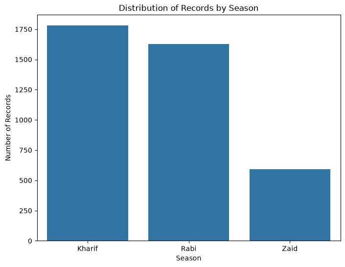

```python
season_counts = df['Season'].value_counts()

plt.figure(figsize=(8, 6))
sns.barplot(x=season_counts.index, y=season_counts.values)

plt.title("Distribution of Records by Season")
plt.xlabel("Season")
plt.ylabel("Number of Records")

plt.show()
```

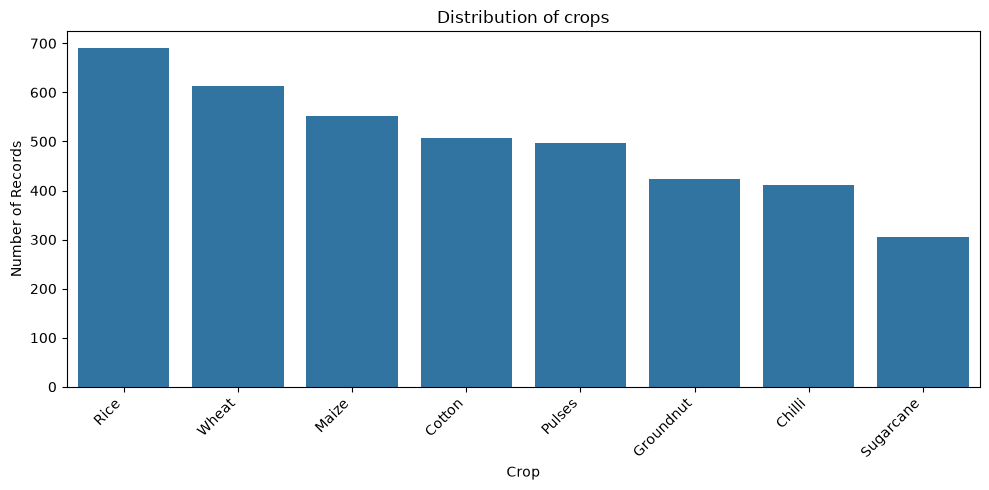

```python
# Univariate: crop distribution

plt.figure(figsize=(10, 5))
sns.countplot(data=df, x="Crop", order=df["Crop"].value_counts().index)
plt.xticks(rotation=45, ha="right")
plt.title("Distribution of crops")
plt.xlabel("Crop")
plt.ylabel("Number of Records")
plt.tight_layout()
plt.show()
```

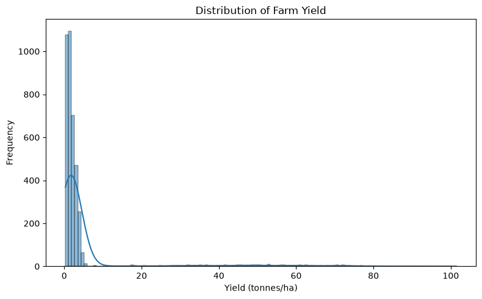

```python
# 1. Univariate: Yield distribution
plt.figure(figsize=(8, 5))
sns.histplot(data=df, x="Yield_Tonnes_Ha", kde=True)
plt.title("Distribution of Farm Yield")
plt.xlabel("Yield (tonnes/ha)")
plt.ylabel("Frequency")
plt.tight_layout()
plt.show()
```

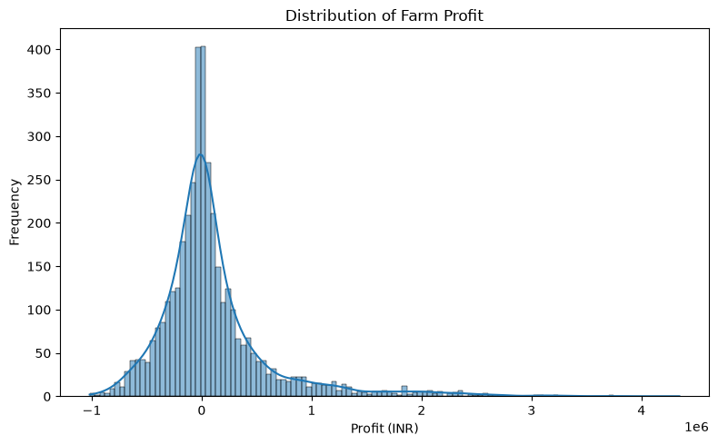

```python
# 2. Univariate: Profit distribution
plt.figure(figsize=(8, 5))
sns.histplot(data=df, x="Profit_INR", kde=True)
plt.title("Distribution of Farm Profit")
plt.xlabel("Profit (INR)")
plt.ylabel("Frequency")
plt.tight_layout()
plt.show()
```

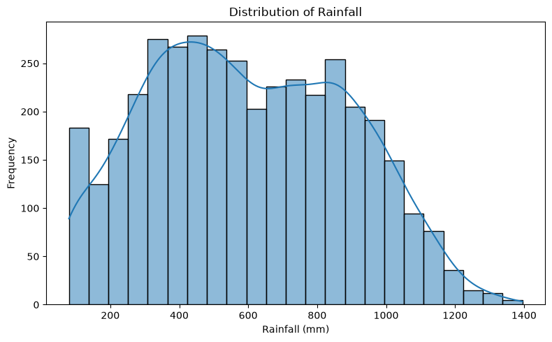

```python
# univariate: Rainfall distribution

plt.figure(figsize=(8, 5))
sns.histplot(data=df, x="Rainfall_mm", kde=True)
plt.title("Distribution of Rainfall")
plt.xlabel("Rainfall (mm)")
plt.ylabel("Frequency")
plt.tight_layout()
plt.show()
```

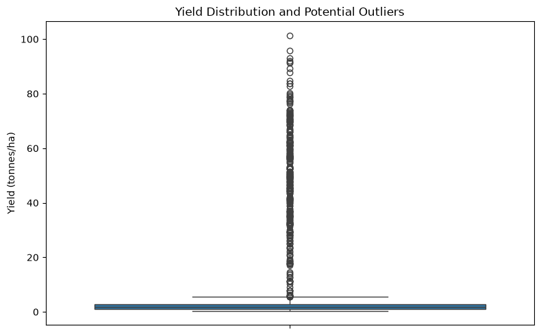

```python
plt.figure(figsize=(8, 5))
sns.boxplot(data=df, y="Yield_Tonnes_Ha")
plt.title("Yield Distribution and Potential Outliers")
plt.ylabel("Yield (tonnes/ha)")
plt.tight_layout()
plt.show()
```

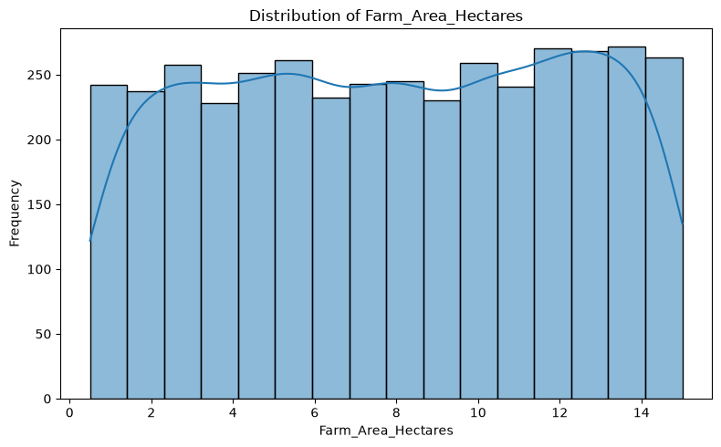

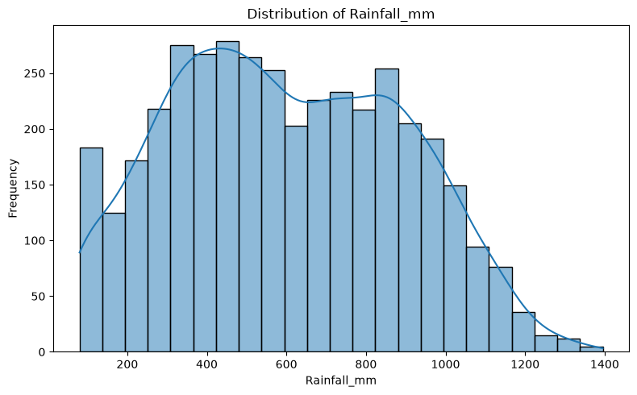

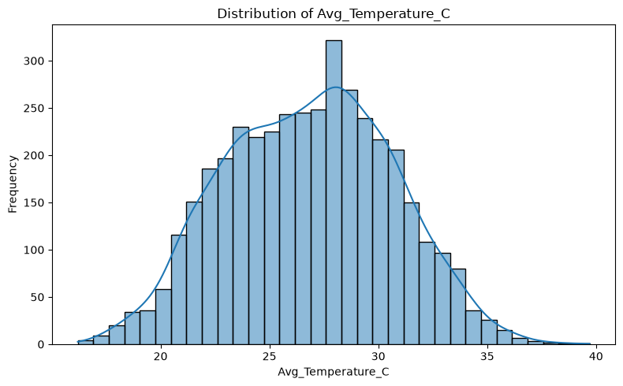

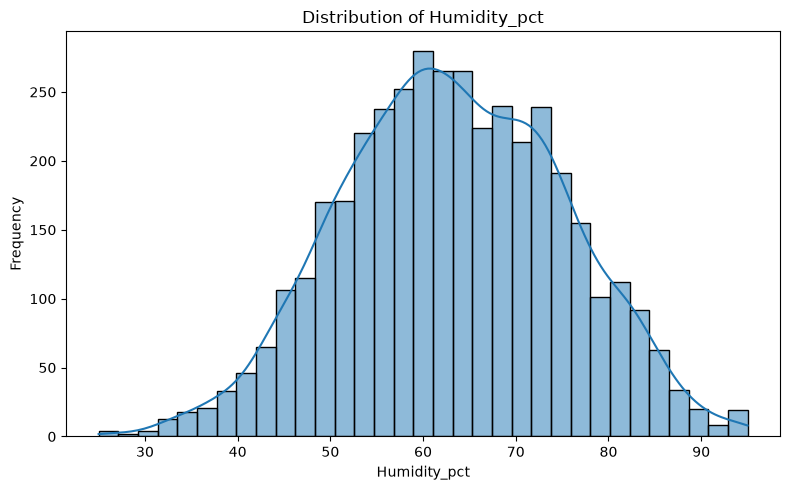

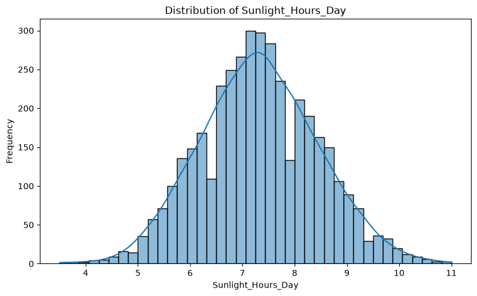

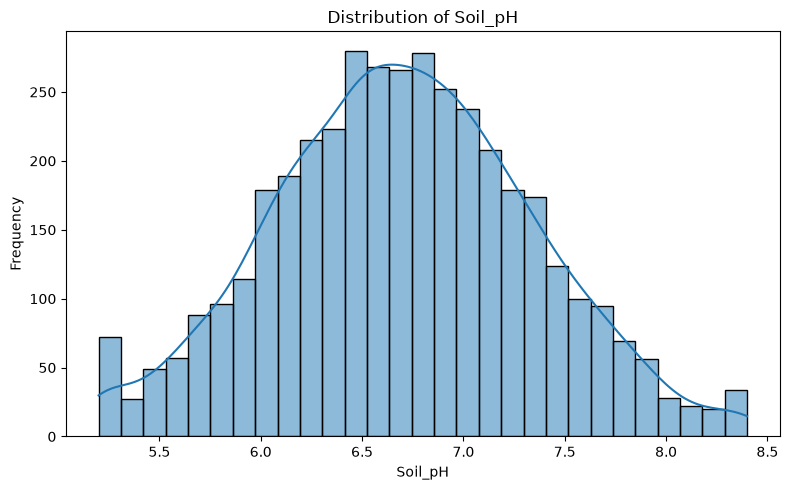

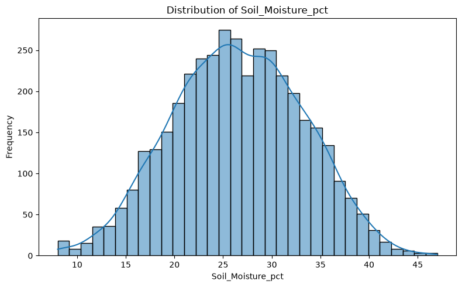

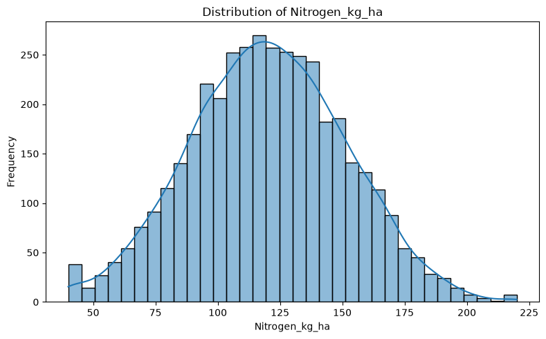

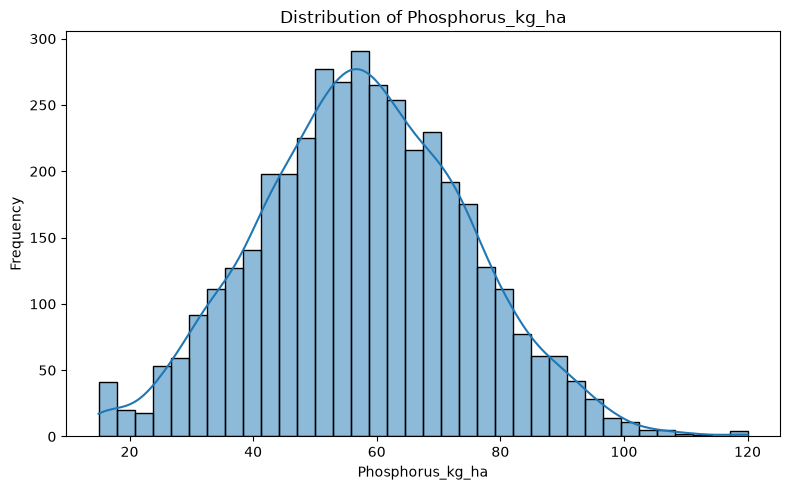

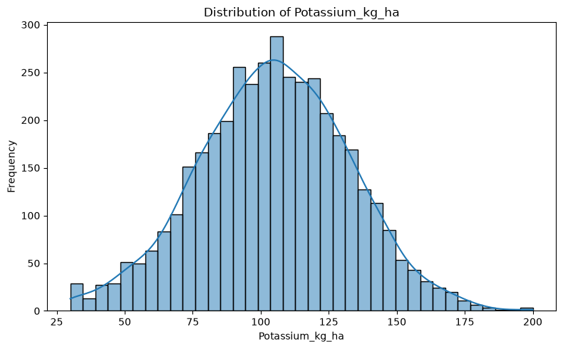

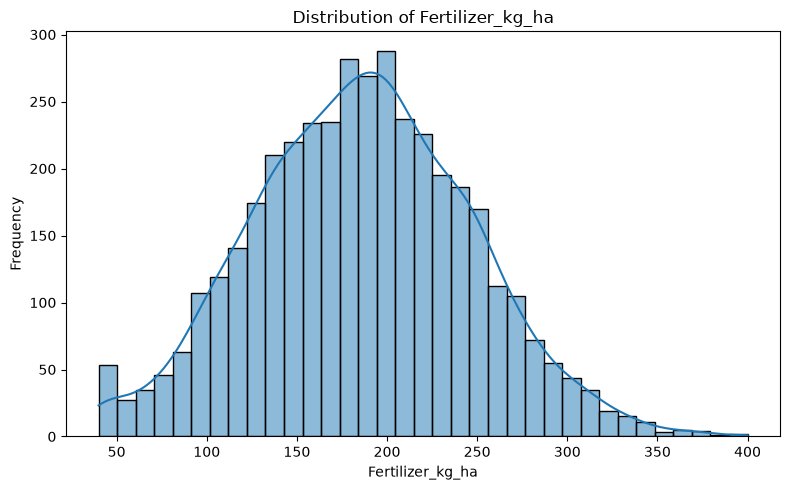

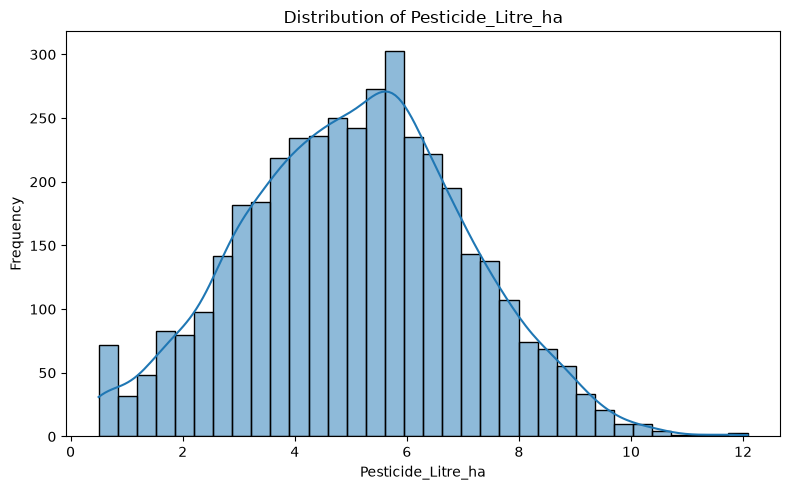

[10 more figures not shown]

```python
numeric_cols = df.select_dtypes(include="number").columns

for col in numeric_cols:
    plt.figure(figsize=(8,5))

    sns.histplot(data=df, x=col, kde=True)

    plt.title(f"Distribution of {col}")
    plt.xlabel(col)
    plt.ylabel("Frequency")
    plt.tight_layout()
    plt.show()
```

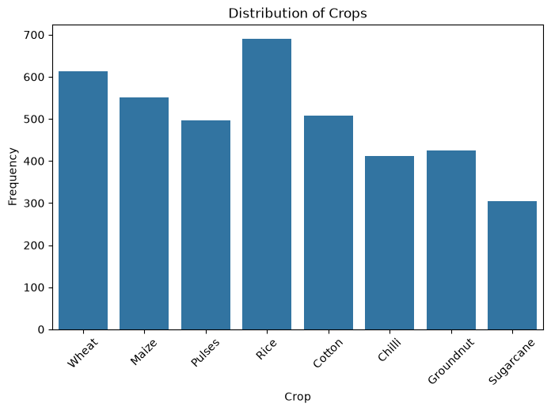

```python
plt.figure(figsize=(8,5))

sns.countplot(data=df, x="Crop")

plt.title("Distribution of Crops")
plt.xlabel("Crop")
plt.ylabel("Frequency")
plt.xticks(rotation=45)

plt.show()
```

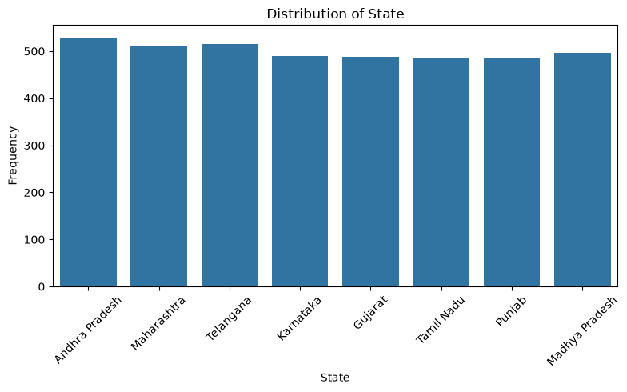

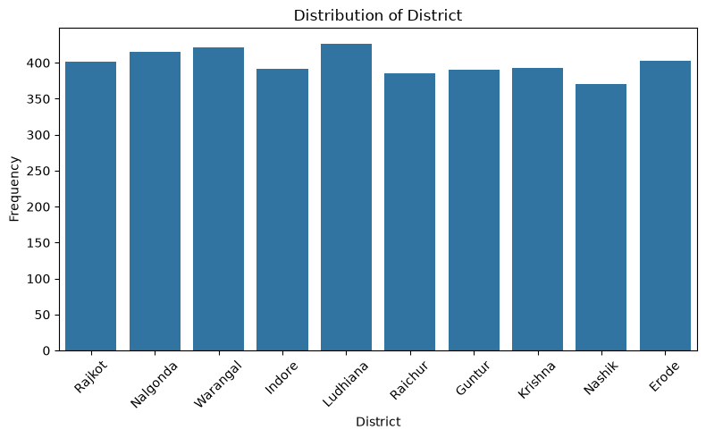

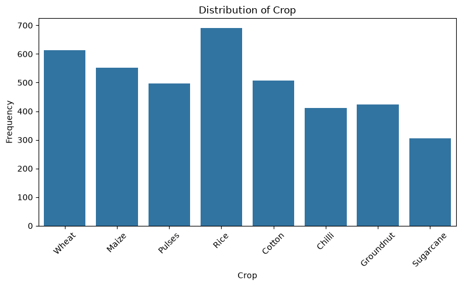

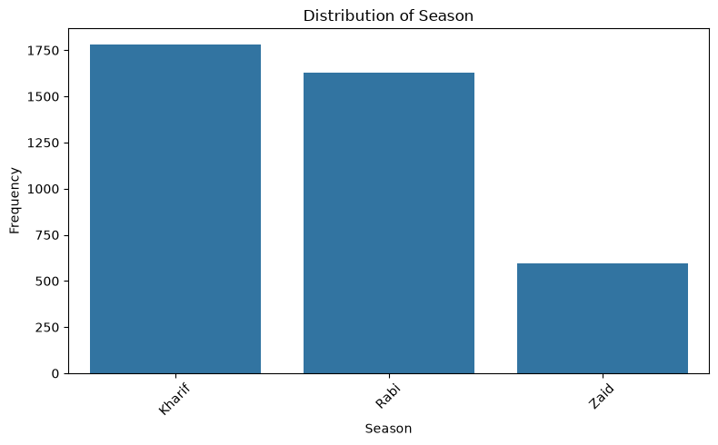

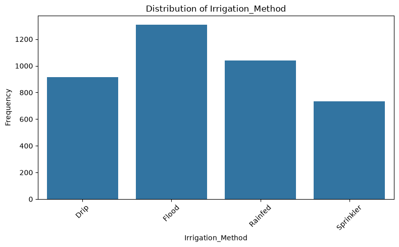

```python
categorical_cols =["State", "District", "Crop", "Season", "Irrigation_Method"]

for col in categorical_cols:
    plt.figure(figsize=(8,5))

    sns.countplot(data=df, x=col)

    plt.title(f"Distribution of {col}")
    plt.xlabel(col)
    plt.ylabel("Frequency")
    plt.xticks(rotation=45)
    plt.tight_layout()
    plt.show()
```

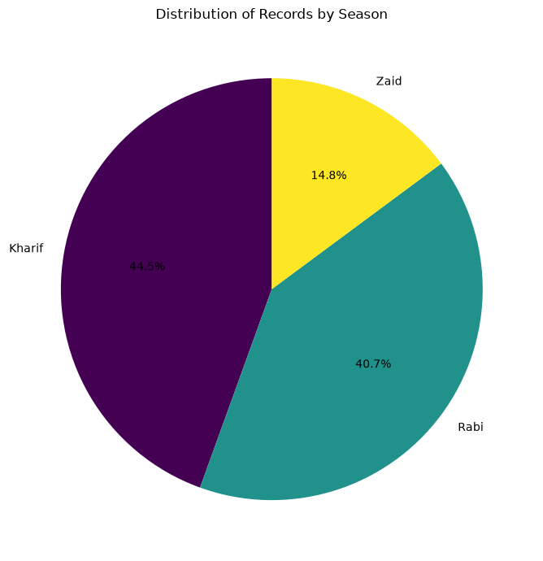

```python
plt.figure(figsize=(7, 7))
df['Season'].value_counts().plot.pie(autopct='%1.1f%%', startangle=90, cmap='viridis')
plt.title('Distribution of Records by Season')
plt.ylabel('') # Hide the default 'Season' label on the y-axis
plt.tight_layout()
plt.show()
```

```python
numeric_columns = df.select_dtypes(include="number").columns.tolist()

print(numeric_columns)
```

```
['Farm_Area_Hectares', 'Rainfall_mm', 'Avg_Temperature_C', 'Humidity_pct', 'Sunlight_Hours_Day', 'Soil_pH', 'Soil_Moisture_pct', 'Nitrogen_kg_ha', 'Phosphorus_kg_ha', 'Potassium_kg_ha', 'Fertilizer_kg_ha', 'Pesticide_Litre_ha', 'Seed_Quality_Score', 'Yield_Tonnes_Ha', 'Production_Tonnes', 'Market_Pr…
```